# **Credit Risk Analysis (SAMPLE PROJECT)**

## INSIGHT

**Credit risk assessment** is a major challenge for financial institutions, such as credit unions and banks, when extending personal loans to consumers. Predicting a customer's likelihood of defaulting on a loan—that is, of not making the required repayments—is one of the primary goals. Financial institutions' stability and profitability can be negatively impacted by loan defaults, which can result in large losses. Development of strong predictive models capable of identifying possible defaulters prior to credit issuance is crucial in order to reduce these risks. Numerous types of financial, demographic, and past customer data are used in these models.

## AIM & OBJECTIVE

- Develop a predictive credit risk model
- Predicting the loan status based on the provided features
- Creation of a machine learning model that can predict the certainity and uncertainity of customer loan defaulting based on the information available in the dataset.

## DATASET

The dataset used in the following project is a public dataset available from kaggle, the dataset is titles as Credit Risk Dataset. The following dataset simulates columns containing Credit Bureau Data.

## APPROACH

#### 1. Data Exploration

- Analysis of variable distribution.
- identifying null/missing and inconsitency in the data.
- Recognise how the independent and dependent variables are related to one another.

#### 2. Data Preprocessing

- Handle missing values.
- Encode categorical variables.
- Normalize/standardize numerical variables.

#### 3. Data Splitting

- split data into training & testing datasets.

#### 4. modelling

- Training data using appropriate machine learning algorithms.
- Train multiple models and tune hyperparameters.

#### 5. Model Evaluation

- Implement AUC-ROC, precision recall and F1 score to evaluate models perfomance.

#### 6. Interpretting Results

- Identify the essential variables for predicting credit risk.
- Analyze and evaluate the patterns & insights obtained from the model.

#### 7. Implementation

- Provide a workable plan for incorporating the predictive model into the credit-granting procedures of the financial institution.

# GOALS

- Prior to extending credit, identify high-risk clients in order to lower the default rate.
- Enhance credit risk assessment accuracy and efficiency.
- Offer insightful information that can be applied to enhance credit strategies and policies.

# CHALLENGES

- Guarding against false positives (identifying a good customer as bad) and false negatives (identifying a bad customer as good) by maintaining model accuracy.
- Preserving impartiality and steering clear of prejudices in the model to guarantee that every customer class is handled fairly.
- Successfully incorporating the model into the financial institution's current systems.
- In order to mitigate risks and make well-informed decisions when granting loans, credit institutions must develop a strong credit risk prediction model.

```python
# Package installation.
! pip install watermark
```

```python
# Libraries

# system libraries
import re
import unicodedata
import itertools

# file manipulation
import pandas as pd
import numpy as np

# Data visualization
import seaborn as sns
import matplotlib.pylab as pl
import matplotlib as m
import matplotlib as mpl
import matplotlib.pyplot as plt
import plotly.express as px
from matplotlib import pyplot as plt

# Configuration for graph width and layout
sns.set_theme(style='whitegrid')
palette='viridis'


# removes the warning alerts
import warnings
warnings.filterwarnings("ignore")

# python version
from platform import python_version
print ('Python versioin in this notebook: ', python_version())

#Load library versions
import watermark

%reload_ext watermark
%watermark -a "Library versions" --iversions
```

```
Python versioin in this notebook:  3.12.4
Author: Library versions

seaborn   : 0.13.2
xarray    : 2023.6.0
ipywidgets: 7.8.1
pandas    : 2.2.2
sys       : 3.12.4 | packaged by Anaconda, Inc. | (main, Jun 18 2024, 15:03:56) [MSC v.1929 64 bit (AMD64)]
numpy     : 1.26.4
watermark : 2.4.3
matplotlib: 3.8.4
plotly    : 5.22.0
re        : 2.2.1
json      : 2.0.9
```

# DATABASE

```python
# setting the display.max_columns option to None
pd.set_option('display.max_columns', None)

#reading the dataset
train_df = pd.read_csv('credit_risk_dataset.csv')
train_df
```

|  | person_age | person_income | person_home_ownership | person_emp_length | loan_intent | loan_grade | loan_amnt | loan_int_rate | loan_status | loan_percent_income | cb_person_default_on_file | cb_person_cred_hist_length |
| --- | --- | --- | --- | --- | --- | --- | --- | --- | --- | --- | --- | --- |
| 0 | 22 | 59000 | RENT | 123.0 | PERSONAL | D | 35000 | 16.02 | 1 | 0.59 | Y | 3 |
| 1 | 21 | 9600 | OWN | 5.0 | EDUCATION | B | 1000 | 11.14 | 0 | 0.10 | N | 2 |
| 2 | 25 | 9600 | MORTGAGE | 1.0 | MEDICAL | C | 5500 | 12.87 | 1 | 0.57 | N | 3 |
| 3 | 23 | 65500 | RENT | 4.0 | MEDICAL | C | 35000 | 15.23 | 1 | 0.53 | N | 2 |
| 4 | 24 | 54400 | RENT | 8.0 | MEDICAL | C | 35000 | 14.27 | 1 | 0.55 | Y | 4 |
| ... | ... | ... | ... | ... | ... | ... | ... | ... | ... | ... | ... | ... |
| 32576 | 57 | 53000 | MORTGAGE | 1.0 | PERSONAL | C | 5800 | 13.16 | 0 | 0.11 | N | 30 |
| 32577 | 54 | 120000 | MORTGAGE | 4.0 | PERSONAL | A | 17625 | 7.49 | 0 | 0.15 | N | 19 |
| 32578 | 65 | 76000 | RENT | 3.0 | HOMEIMPROVEMENT | B | 35000 | 10.99 | 1 | 0.46 | N | 28 |
| 32579 | 56 | 150000 | MORTGAGE | 5.0 | PERSONAL | B | 15000 | 11.48 | 0 | 0.10 | N | 26 |
| 32580 | 66 | 42000 | RENT | 2.0 | MEDICAL | B | 6475 | 9.99 | 0 | 0.15 | N | 30 |

32581 rows × 12 columns

```python
# data info
train_df.info()
```

```
<class 'pandas.core.frame.DataFrame'>
RangeIndex: 32581 entries, 0 to 32580
Data columns (total 12 columns):
 #   Column                      Non-Null Count  Dtype
---  ------                      --------------  -----
 0   person_age                  32581 non-null  int64
 1   person_income               32581 non-null  int64
 2   person_home_ownership       32581 non-null  object
 3   person_emp_length           31686 non-null  float64
 4   loan_intent                 32581 non-null  object
 5   loan_grade                  32581 non-null  object
 6   loan_amnt                   32581 non-null  int64
 7   loan_int_rate               29465 non-null  float64
 8   loan_status                 32581 non-null  int64
 9   loan_percent_income         32581 non-null  float64
 10  cb_person_default_on_file   32581 non-null  object
 11  cb_person_cred_hist_length  32581 non-null  int64
dtypes: float64(3), int64(5), object(4)
memory usage: 3.0+ MB
```

```python
# datatypes info
train_df.dtypes
```

```
person_age                      int64
person_income                   int64
person_home_ownership          object
person_emp_length             float64
loan_intent                    object
loan_grade                     object
loan_amnt                       int64
loan_int_rate                 float64
loan_status                     int64
loan_percent_income           float64
cb_person_default_on_file      object
cb_person_cred_hist_length      int64
dtype: object
```

```python
# total no.of rows and columns
train_df.shape
```

```
(32581, 12)
```

# Exploratory Data Analysis

```python
print("\nDescriptive statictics of the training data")
train_df.describe().T
```

```
Descriptive statictics of the training data
```

|  | count | mean | std | min | 25% | 50% | 75% | max |
| --- | --- | --- | --- | --- | --- | --- | --- | --- |
| person_age | 32581.0 | 27.734600 | 6.348078 | 20.00 | 23.00 | 26.00 | 30.00 | 144.00 |
| person_income | 32581.0 | 66074.848470 | 61983.119168 | 4000.00 | 38500.00 | 55000.00 | 79200.00 | 6000000.00 |
| person_emp_length | 31686.0 | 4.789686 | 4.142630 | 0.00 | 2.00 | 4.00 | 7.00 | 123.00 |
| loan_amnt | 32581.0 | 9589.371106 | 6322.086646 | 500.00 | 5000.00 | 8000.00 | 12200.00 | 35000.00 |
| loan_int_rate | 29465.0 | 11.011695 | 3.240459 | 5.42 | 7.90 | 10.99 | 13.47 | 23.22 |
| loan_status | 32581.0 | 0.218164 | 0.413006 | 0.00 | 0.00 | 0.00 | 0.00 | 1.00 |
| loan_percent_income | 32581.0 | 0.170203 | 0.106782 | 0.00 | 0.09 | 0.15 | 0.23 | 0.83 |
| cb_person_cred_hist_length | 32581.0 | 5.804211 | 4.055001 | 2.00 | 3.00 | 4.00 | 8.00 | 30.00 |

```python
# analysis on numerical & categorical variables
ctg_features = train_df.select_dtypes(include=['object']).columns
num_features = train_df.select_dtypes(include=[np.number]).columns

print("\n Categorical variables:\n", ctg_features)
print("\n Numerical variables: \n", num_features)
```

```
 Categorical variables:
 Index(['person_home_ownership', 'loan_intent', 'loan_grade',
       'cb_person_default_on_file'],
      dtype='object')

 Numerical variables:
 Index(['person_age', 'person_income', 'person_emp_length', 'loan_amnt',
       'loan_int_rate', 'loan_status', 'loan_percent_income',
       'cb_person_cred_hist_length'],
      dtype='object')
```

```python
# Analysis of categorical variables
for col in ctg_features:
    print(f"\nDistribution of categorical variable {col}:")
    print(train_df[col].value_counts())
```

```
Distribution of categorical variable person_home_ownership:
person_home_ownership
RENT        16446
MORTGAGE    13444
OWN          2584
OTHER         107
Name: count, dtype: int64

Distribution of categorical variable loan_intent:
loan_intent
EDUCATION            6453
MEDICAL              6071
VENTURE              5719
PERSONAL             5521
DEBTCONSOLIDATION    5212
HOMEIMPROVEMENT      3605
Name: count, dtype: int64

Distribution of categorical variable loan_grade:
loan_grade
A    10777
B    10451
C     6458
D     3626
E      964
F      241
G       64
Name: count, dtype: int64

Distribution of categorical variable cb_person_default_on_file:
cb_person_default_on_file
N    26836
Y     5745
Name: count, dtype: int64
```

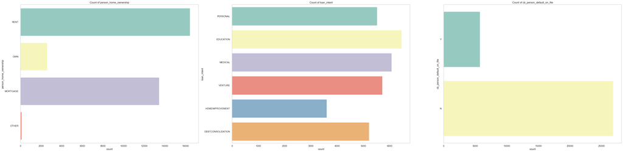

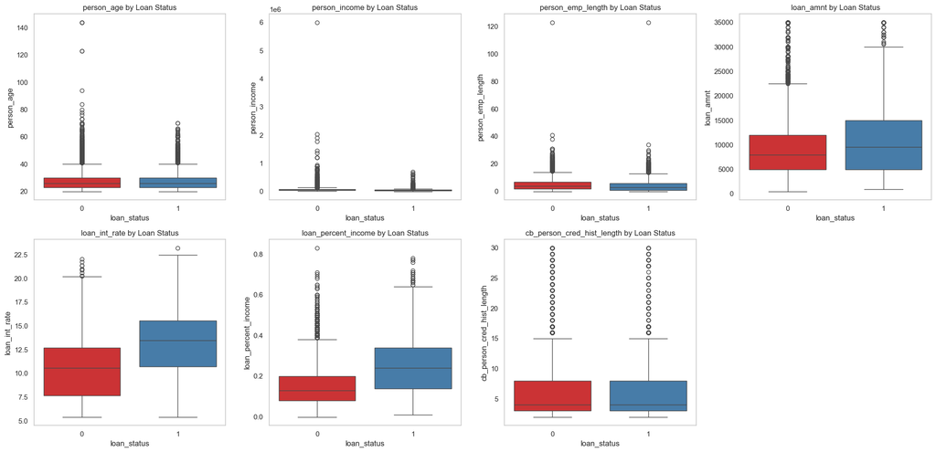

```python
# 2. Counting categorical variables
plt.figure(figsize=(40.5, 10))
ctg_cols = ['person_home_ownership', 'loan_intent', 'cb_person_default_on_file']
for i, col in enumerate(ctg_cols, 1):
    plt.subplot(1, 3, i)
    sns.countplot(y=train_df[col], palette = 'Set3')
    plt.title(f'Count of {col}')
    plt.grid(False)
    plt.tight_layout()
plt.show()

# 4. Comparison of distributions
num_cols = ['person_age', 'person_income','person_emp_length', 'loan_amnt',
                  'loan_int_rate', 'loan_percent_income',
                  'cb_person_cred_hist_length']

# Boxplots chart
print()
print()
plt.figure(figsize=(20.5, 10))
for i, col in enumerate(num_cols, 1):
    plt.subplot(2, 4, i)
    sns.boxplot(x='loan_status', y=col, data=train_df, palette = 'Set1')
    plt.title(f'{col} by Loan Status')
    plt.grid(False)
plt.tight_layout()
plt.show()
```

Graphs comparing the distributions of categorical variables are displayed above. These graphs are essential for data analysis because they show the distribution of various categories with respect to a given variable.

In descriptive statistics and exploratory data analysis, comparing distributions is a crucial technique that offers important insights into the pattern, dispersion, and central tendency of data. These graphs can be bar graphs, box plots, histograms, and more; each has benefits and applications. Histograms, for instance, can be used to see how a continuous variable is distributed and to determine how frequently events occur within various ranges. In contrast, box plots are a great tool for determining outliers and comprehending the distribution of data in terms of quartiles. When comparing the frequency of various categories within a categorical variable, bar charts are frequently utilised. Furthermore, significant patterns and differences that can inform choice-making and the development of predictions can be found by comparing the distributions of various groups or categories. These graphs are widely utilised in many different contexts, including epidemiological studies, performance analysis, and market research. These visualisations allow us to identify patterns, correlations, and even potential anomalies in the data, which makes for a more thorough and precise analysis.

```
Distribution of target variable 'Loan Status':
loan_status
0    25473
1     7108
Name: count, dtype: int64
```

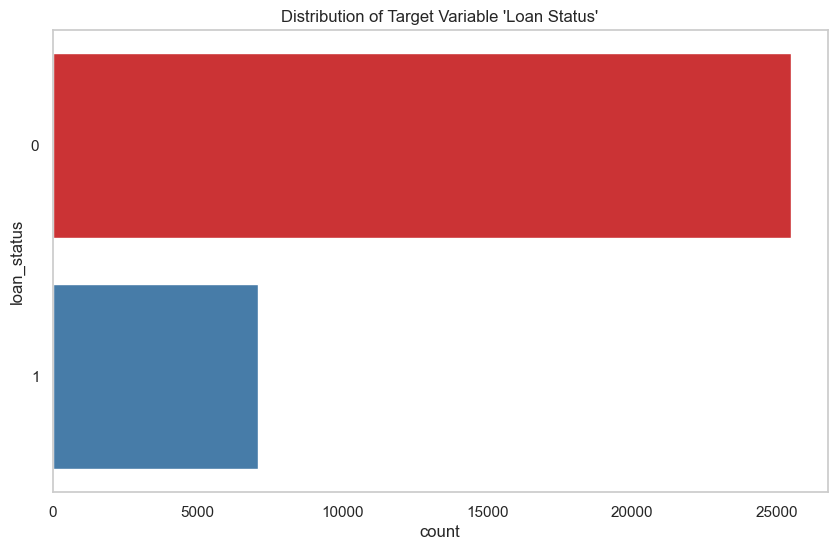

```python
# Analysis of target variable 'Target'
print("\nDistribution of target variable 'Loan Status':")
print(train_df['loan_status'].value_counts())
plt.figure(figsize=(10, 6))
sns.countplot(data=train_df, y='loan_status', palette='Set1')
plt.title("Distribution of Target Variable 'Loan Status'")
plt.grid(False)
plt.show()
```